# 10-701 Recitation 1

## Goals:

- HW1 linear algebra review
- HW1 probability review
- Lecture 1 and Lecture 2 review

## Sources:

- 10-701 [Lecture 1](http://www.cs.cmu.edu/~tom/10701-S20/Intro-DTreesAndOverfitting-1-13-2020.pdf) and [Lecture 2](http://www.cs.cmu.edu/~tom/10701-S20/Overfitting_ProbReview-1-15-2020.pdf)
- [Andrew Moore tutorial](http://www.cs.cmu.edu/afs/cs/Web/People/awm/tutorials/infogain11.pdf)
- 10-601 Intro to ML recitation 1 (Sida, Rawal, Rongye, George)

```python
import numpy as np
import matplotlib.pyplot as plt
import matplotlib
font = {'family' : 'normal',
        'weight' : 'normal',
        'size'   : 16}

matplotlib.rc('font', **font)
```

## Linear Algebra review

Consider the matrix X and the vectors y and z:

$$ X = \begin{bmatrix} 1 & 5 \\ 2 & 3 \end{bmatrix}, ~ ~ ~ y = \begin{bmatrix} 1 \\ 2 \end{bmatrix}, ~ ~ ~ z = \begin{bmatrix} 2 \\ 3 \end{bmatrix}. $$

#### Question 1:

- What is the transpose of matrix X?

#### Question 2:

- What is the inner product (dot product) of the vectors y and z?

#### Question 3:

- What is the product of Xy?

## Linear Algebra review

Let $$ X = \begin{bmatrix} 1 & 3 & 2 \\ 1 & 4 & 10 \\ 2 & 3 & 1 \end{bmatrix}, ~ ~ ~ Y = \begin{bmatrix} 2 & 4 & 5 \\ 1 & 2 & 3 \\ 5 & 6 & 1 \end{bmatrix}. $$

#### Question 4:

- What is the top right value of the matrix XY

## Linear Algebra review

#### Question 5:

If X is a 2x3 matrix and Y is a 3x4 matrix, which is the following is true:

- a - XY is a 3x3 matrix
- b - YX does not exist
- c - YX is a 2x4 matrix
- d - XY is a 2x4 matrix

#### Question 6:

If $ A = \begin{bmatrix} 1 & 5 \\ 2 & 3 \end{bmatrix}$ then which of the following are true?

- a - A is a 2x3 matrix
- b - A is invertible
- c - A has determinant as 0
- d - A has trace 5

## Calculus

#### Question 1:

Evaluate the derivative of y with respect to x, where $$ y = x^4+x-3, ~ ~ ~ ~ \text{for} ~ ~ x=3$$

#### Question 2:

What is the derivative of y with respect to x, where $$ y = sin(3x)$$

#### Question 3:

Evaluate the derivative of y with respect to x, where $$ y = 4x^3e^{5x}$$

## Calculus

#### Question 4:

What are the coordinates (x,f(x)) of the maximum point of the function: $$ f(x) = -x^2 +6x-3$$

#### Question 5:

Find the partial derivatives $\frac{\partial f}{\partial x}$ and $\frac{\partial f}{\partial y}$ of the function:

$$ f(x,y) = x^2y^5+\cos(x)\sin(y)-4x-7$$

#### Question 6:

What is the integral of the function below with respect to x?

$$ 6x^2-\sin(x)+\frac{1}{x}$$

## Probability and Statistics

#### Expectation and variance:

The variance of a zero-mean random variable X is $\sigma^2$

1- What is the variance of 3X?

2- What is the variance of X+4?

3- What is the mean of 3X?

4- What is the mean of X+4?

# Probability and Statistics

#### Coin Toss

Consider five coin toss outcomes S = [1, 0, 0, 1, 0], where 1 denotes head and 0 denotes tail.

1- What is the sample mean?

2- What is the (uncorrected) sample variance?

3- What is the probability of observing this outcome sequence? Assume the coin is fair, i.e. P(X=1) = P(X=0) = 0.5

# Entropy and Information Gain

We saw in class that information gain can be used to determine which variable to split on while constructing a decision tree.

### Entropy

The entropy of a (discrete) random variable X taking values $V_1...V_m$ is defined as:

$$H(X)=-\sum_{i=1}^m P(X=V_i)\log_2(P(X=V_i))$$

Entropy is a function of the probability distribution of X. If X is uniform, the entropy will be large (we have little information about the value of X):

```
H(X) = 2.0
```

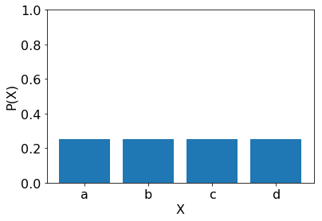

```python
Values_X = np.array(['a','b','c','d'])
P_X = np.array([1/4,1/4,1/4,1/4])

plt.bar(np.arange(4), P_X, tick_label = Values_X)
plt.ylabel('P(X)'); plt.xlabel('X'); plt.ylim([0,1])

H_X = -np.sum(P_X*np.log2(P_X)) # python * is element wise, use np.dot for matrix multiplication

print('H(X) = {}'.format(H_X))
```

If X is not uniform, and instead has some very likely and very unlikely values, entropy will be low (we have more information about X):

```
H(X) = 1.75
```

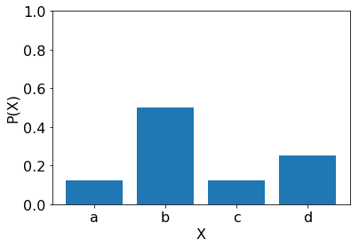

```python
Values_X = np.array(['a','b','c','d'])
P_X = np.array([1/8,1/2,1/8,1/4])

plt.bar(np.arange(4), P_X, tick_label = Values_X)
plt.ylabel('P(X)'); plt.xlabel('X'); plt.ylim([0,1])

H_X = -np.sum(P_X*np.log2(P_X)) # python * is element wise, use np.dot for matrix multiplication

print('H(X) = {}'.format(H_X))
```

Think of encoding the values of X in the second case using the following code on a serial channel:

| X | a | b | c | d |
| --- | --- | --- | --- | --- |
| P(X) | 1/8 | 1/2 | 1/8 | 1/4 |
| code(X) | 00 | 01 | 10 | 11 |
| N(X) (bits) | 2 | 2 | 2 | 2 |

The expected value of the number of bits to use $N$ is: $$E[N] = \sum_{i=1}^4 N_i\times P(X=V_i) = 2\times1/8 + 2\times1/2 + 2\times1/8 + 2\times1/4 = 2$$

Consider the code:

| X | a | b | c | d |
| --- | --- | --- | --- | --- |
| P(X) | 1/8 | 1/2 | 1/8 | 1/4 |
| code(X) | 110 | 0 | 111 | 10 |
| N(X) (bits) | 3 | 1 | 3 | 2 |

The expected value for the number of bits:

$$E[N] = \sum_{i=1}^4 N_i\times P(X=V_i) = 3\times1/8 + 1\times1/2 + 3\times1/8 + 2\times1/4 = 1.75$$

Entropy corresponds to the smallest number of bits on average per symbol needed to transmit symbols on a serial channel.

### Entropy of coin flip example

As an example, here is how the entropy of a coin flip varies as the probability of heads vary. When the probability is 0.5, we have the least information about the outcome (highest entropy).

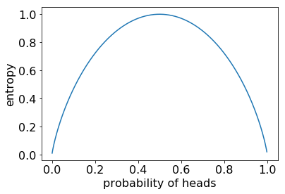

```python
x = np.arange(0.001,0.999,0.001)
H_x = -(x*np.log2(x)+ (1-x)*np.log2(1-x))
plt.plot(x,H_x)
plt.xlabel('probability of heads'); plt.ylabel('entropy')
```

## Conditional Entropy

Conditional entropy of Y on X corresponds to how uncertain Y is given the value of X. Consider the example where X is the neighborhood in which a 10-701 student lives in, and Y corresponds to whether the student walks to school:

| Neighborhood | Walks to school |
| --- | --- |
| Squirrel-Hill | No |
| Shadyside | Yes |
| Oakland | No |
| Squirrel-Hill | Yes |
| Squirrel-Hill | Yes |
| Oakland | No |
| Shadyside | Yes |
| Squirrel-Hill | No |

The conditional entropy of Y given X is computed as:

$$H(Y|X)=\sum_{i=1}^m P(X=V_i)H(Y|X=V_i)$$

It corresponds to how much information is given about Y once we know the value of X. In this case what is $H(Y|X)$?:

| $V_i$ | $$H(Y | X=V_i)$$ |
| --- | --- | --- |
| Squirrel-Hill |  |  |
| Shadyside |  |  |
| Oakland |  |  |

Conditional entropy of Y on X corresponds to how uncertain Y is given the value of X. Consider the example where X is the neighborhood in which a 10-701 student lives in, and Y corresponds to whether the student walks to school:

| Neighborhood | Walks to school |
| --- | --- |
| Squirrel-Hill | No |
| Shadyside | Yes |
| Oakland | No |
| Squirrel-Hill | Yes |
| Squirrel-Hill | Yes |
| Oakland | No |
| Shadyside | Yes |
| Squirrel-Hill | No |

The conditional entropy of Y given X is computed as:

$$H(Y|X)=\sum_{i=1}^m P(X=V_i)H(Y|X=V_i)$$

It corresponds to how much information is given about Y once we know the value of X. In this case:

| $V_i$ | $H(Y | X=V_i)$ |
| --- | --- | --- |
| Squirrel-Hill | $$0.5\times\log_2(0.5) + 0.5\times\log_2(0.5) = 1$$ |  |
| Shadyside | $$ 0\times\log_2(0) + 1\times\log_2(1) = 0$$ |  |
| Oakland | $$1\times\log_2(0) + 0\times\log_2(1) = 0$$ |  |

$$H(Y|X)= 0.5\times1 + 0.25\times0 + 0.25\times0 = 0.5$$

$$H(Y|X)=\sum_{i=1}^m P(X=V_i)H(Y|X=V_i)$$

| $V_i$ | $H(Y | X=V_i)$ |
| --- | --- | --- |
| Squirrel-Hill | $$0.5\times\log_2(0.5) + 0.5\times\log_2(0.5) = 1$$ |  |
| Shadyside | $$ 0\times\log_2(0) + 1\times\log_2(1) = 0$$ |  |
| Oakland | $$1\times\log_2(0) + 0\times\log_2(1) = 0$$ |  |

$$H(Y|X)= 0.5\times1 + 0.25\times0 + 0.25\times0 = 0.5$$

#### Question 1

- What happens to H(Y|X) if all the Squirrel-Hill student do not walk to school? What would that mean about how useful X is?

#### Question 2

- What happens to H(Y|X) if the following students are changed? What is it telling us about feature X?

| Neighborhood | Walks to school |
| --- | --- |
| Squirrel-Hill | No |
| Shadyside | Yes |
| Oakland | **Yes** |
| Squirrel-Hill | Yes |
| Squirrel-Hill | Yes |
| Oakland | No |
| Shadyside | **No** |
| Squirrel-Hill | No |

#### Question 3

- What does conditional entropy represent?

## Information Gain

How much would knowing about X help me? (how many bits would I save?)

$$\text{IG}(Y|X) = H(Y) - H(Y|X)$$

We use Information Gain to find features to construct a decision tree.

## Information Gain example

| X1 | X2 | X3 | Y |
| --- | --- | --- | --- |
| 1 | 1 | 1 | + |
| 1 | 1 | 0 | + |
| 0 | 0 | 1 | - |
| 1 | 0 | 0 | - |

H(Y) = 1

H(Y|X1) = ?

H(Y|X2) = ?

H(Y|X3) = ?

## Information Gain example

| X1 | X2 | X3 | Y |
| --- | --- | --- | --- |
| 1 | 1 | 1 | + |
| 1 | 1 | 0 | + |
| 0 | 0 | 1 | - |
| 1 | 0 | 0 | - |

H(Y) = 1

## Information Gain example

| X1 | X2 | X3 | Y |
| --- | --- | --- | --- |
| 1 | 1 | 1 | + |
| 1 | 1 | 0 | + |
| 0 | 0 | 1 | - |
| 1 | 0 | 0 | - |

H(Y) = 1

- $H(Y|X2=1) = -1\times\log_2(1) = 0$
- $H(Y|X2=0) = -1\times\log_2(1) = 0$
- $H(Y|X2) = 1/2 * H(Y|X2=1) +1/2* H(Y|X2=0)=0$
- $\text{IG}(Y|X2) =1$

## Information Gain example

| X1 | X2 | X3 | Y |
| --- | --- | --- | --- |
| 1 | 1 | 1 | + |
| 1 | 1 | 0 | + |
| 0 | 0 | 1 | - |
| 1 | 0 | 0 | - |

H(Y) = 1

- $H(Y|X3=1) = -1/2\times\log_2(1/2) -1/2\times\log_2(1/2) = 1$
- $H(Y|X3=0) = -1/2\times\log_2(1/2) -1/2\times\log_2(1/2) = 1$
- $H(Y|X3) = 1/2 * H(Y|X3=1) +1/2* H(Y|X3=0)=1$
- $\text{IG}(Y|X3) = 0$

## Information Gain example

| X1 | X2 | X3 | Y |
| --- | --- | --- | --- |
| 1 | 1 | 1 | + |
| 1 | 1 | 0 | + |
| 0 | 0 | 1 | - |
| 1 | 0 | 0 | - |

$\text{IG}(Y|X2) = 1$, X2 perfectly predicts Y (we didn't even need to compute this, after all).

## In class example

```python
X_names = np.array(['Outlook','Temperature','Humidity','Wind'])

Weather = np.array([['Sunny','Hot','High','Weak'],
                    ['Sunny','Hot','High','Strong'],
                    ['Overcast','Hot','High','Weak'],
                    ['Rain','Mild','High','Weak'],
                    ['Rain','Cool','Normal','Weak'],
                    ['Rain','Cool','Normal','Strong'],
                    ['Overcast','Cool','Normal','Strong'],
                    ['Sunny','Mild','High','Weak'],
                    ['Sunny','Cool','Normal','Weak'],
                    ['Rain','Mild','Normal','Weak'],
                    ['Sunny','Mild','Normal','Strong'],
                    ['Overcast','Mild','High','Strong'],
                    ['Overcast','Hot','Normal','Weak'],
                    ['Rain','Mild','High','Strong']])

PlayTennis = np.array([['No'],['No'],['Yes'],['Yes'],['Yes'],
                       ['No'],['Yes'],['No'],['Yes'],['Yes'],
                       ['Yes'],['Yes'],['Yes'],['No']])

def entropy(vec):
    # Computes entropy of a vector of discrete variables
    values = np.unique(vec)
    p_X = np.array([np.mean(vec==v) for v in values])
    return -np.sum(p_X*np.log2(p_X))

H_Y = entropy(PlayTennis)
print(H_Y)
```

```
0.9402859586706311
```

Compute $\text{IG}(Y|X)$ for every X:

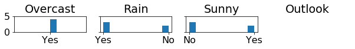

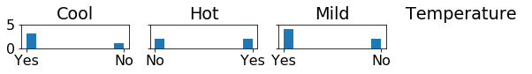

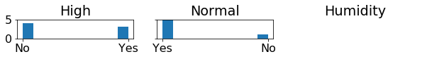

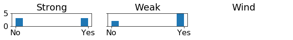

```python
IG = np.zeros(len(X_names))
for i_var, X_var in enumerate(X_names):
    values = np.unique(Weather[:,i_var])
    n_values = len(values)
    H_YX = np.zeros(n_values)
    f, axs = plt.subplots(1, n_values+1, sharey=True, figsize = (10,0.5))
    for i_ax,ax in enumerate(axs[:-1]):
        value = values[i_ax]
        # plot histogram
        PT = PlayTennis[Weather[:,i_var]==value]
        ax.hist(PT); ax.set_title(value); ax.set_ylim([0,5])
        # compute H(Y|X=V_i)xP(X=V_i)
        P_V_i = np.mean(Weather[:,i_var]==value)
        H_YX[i_ax] = entropy(PT)*P_V_i
    axs[-1].set_title(X_var); axs[-1].axis('off')
    IG[i_var] = H_Y - np.sum(H_YX)
```

## Information Gain, first level:

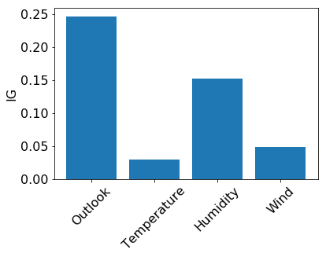

```python
plt.bar(np.arange(len(X_names)),IG)
plt.xticks(ticks=np.arange(len(X_names)),labels=X_names,rotation=45);
plt.ylabel('IG');
```

We pick "Outlook" as a first variable to split on:

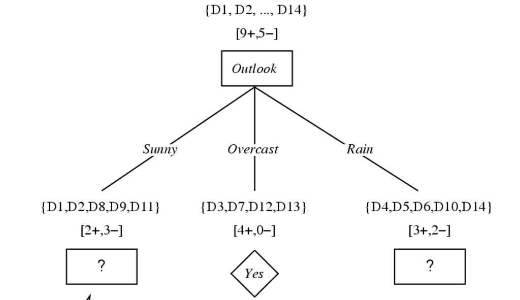

We have to keep splitting for Sunny and Rain

```python
print('Overcast = Sunny')
Weather_subset = Weather[Weather[:,0]=='Sunny',1:]
PlayTennis_subset = PlayTennis[Weather[:,0]=='Sunny']

print('Weather = {}'.format(Weather_subset))
print('PlayTennis = {}'.format(PlayTennis_subset))

H_Y = entropy(PlayTennis_subset)
print(H_Y)
```

```
Overcast = Sunny
Weather = [['Hot' 'High' 'Weak']
 ['Hot' 'High' 'Strong']
 ['Mild' 'High' 'Weak']
 ['Cool' 'Normal' 'Weak']
 ['Mild' 'Normal' 'Strong']]
PlayTennis = [['No']
 ['No']
 ['No']
 ['Yes']
 ['Yes']]
0.9709505944546686
```

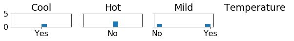

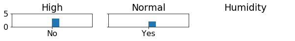

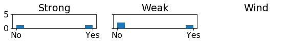

```python
IG = np.zeros(len(X_names)-1)
for i_var, X_var in enumerate(X_names[1:]):
    values = np.unique(Weather_subset[:,i_var])
    n_values = len(values)
    H_YX = np.zeros(n_values)
    f, axs = plt.subplots(1, n_values+1, sharey=True, figsize = (10,0.5))
    for i_ax,ax in enumerate(axs[:-1]):
        value = values[i_ax]
        # plot histogram
        PT = PlayTennis_subset[Weather_subset[:,i_var]==value]
        ax.hist(PT); ax.set_title(value); ax.set_ylim([0,5])
        # compute H(Y|X=V_i)xP(X=V_i)
        P_V_i = np.mean(Weather_subset[:,i_var]==value)
        H_YX[i_ax] = entropy(PT)*P_V_i
    axs[-1].set_title(X_var); axs[-1].axis('off')
    IG[i_var] = H_Y - np.sum(H_YX)
```

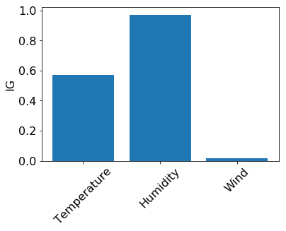

```python
plt.bar(np.arange(len(X_names[1:])),IG)
plt.xticks(ticks=np.arange(len(X_names[1:])),labels=X_names[1:],rotation=45);
plt.ylabel('IG');
```